# Questionnaire e-TAC sur le Travail collectif et outils numériques en milieu scolaire: présentation des questions

## Usage collectif des services numériques

470 enseignants des collèges et 313 des écoles déclarent utiliser au moins un service numérique pour travailler avec leurs collègues.

*Pour travailler avec mes collègues, j’utilise les services numériques suivants:*

| `ServicesNum_` | Effectif au collège | Effectif en élémentaire | % au collège | % en élémentaire | % Global |
| --- | --- | --- | --- | --- | --- |
| Courriel (e-mail) `Mail` | 401 | 258 | 85.3 | 82.4 | 84.2 |
| SMS `Sms` | 238 | 147 | 50.6 | 47 | 49.2 |
| Sites web `Web` | 139 | 121 | 29.6 | 38.7 | 33.2 |
| Espace Numérique de Travail `ENT` | 275 | 24 | 58.5 | 7.7 | 38.2 |
| Stockage et partage de fichiers `Drive` | 78 | 50 | 16.6 | 16 | 16.3 |
| Réseaux sociaux généralistes `FB` | 49 | 27 | 10.4 | 8.6 | 9.7 |
| Outils collaboratifs partagés `Collab` | 51 | 24 | 10.9 | 7.7 | 9.6 |
| Bavardage (Chat) `Chat` | 40 | 16 | 8.5 | 5.1 | 7.2 |
| Réseaux professionnels enseignants `Viaed` | 30 | 23 | 6.4 | 7.3 | 6.8 |
| Cours en ligne (Mooc) `Mooc` | 6 | 2 | 1.3 | 0.6 | 1 |
| Carnets en ligne (blogs) `Blog` | 6 | 7 | 1.3 | 2.2 | 1.7 |
| Forum en ligne `Forum` | 3 | 6 | 0.6 | 1.9 | 1.1 |
| Visio-conférence `Skype` | 2 | 4 | 0.4 | 1.3 | 0.8 |
| autre service `other` | 19 | 16 | 4 | 5.1 | 4.5 |
| TOTAL | 470 | 313 |  |  | n =783 |

`Mail` (p 32.4%) `Sms` (p 35%) `Web` (p 1%) `ENT` (p 3.410^{-44}%) `Drive` (p 89.5%) `FB` (p 47.8%) `Collab` (p 17.4%) `Chat` (p 9.6%) `Viaed` (p 70.3%) `Mooc` (p 61.3%) `Blog` (p 45.7%) `Forum` (p 19.3%) `Skype` (p 35.7%) `other` (p 59.4%)

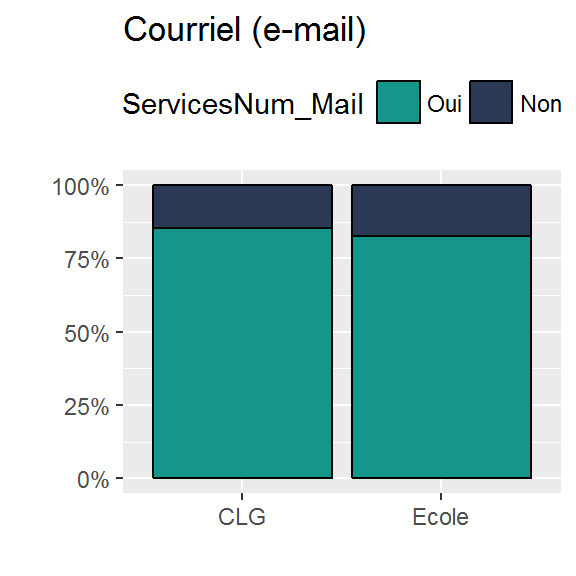

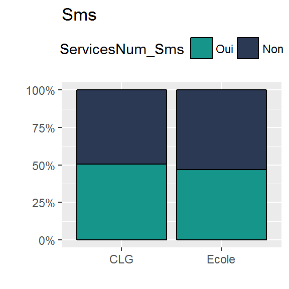

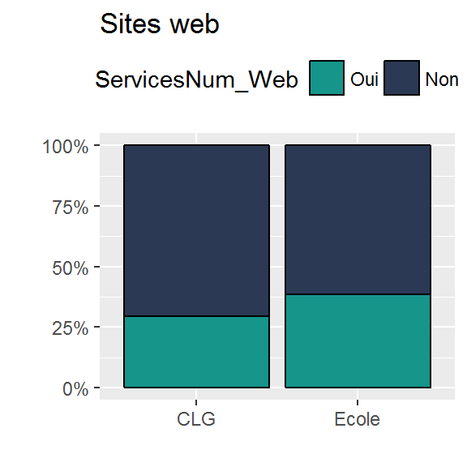

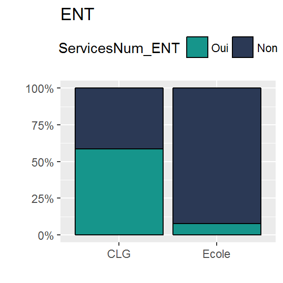

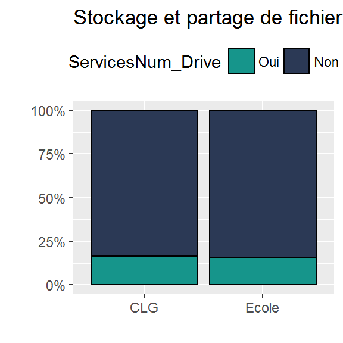

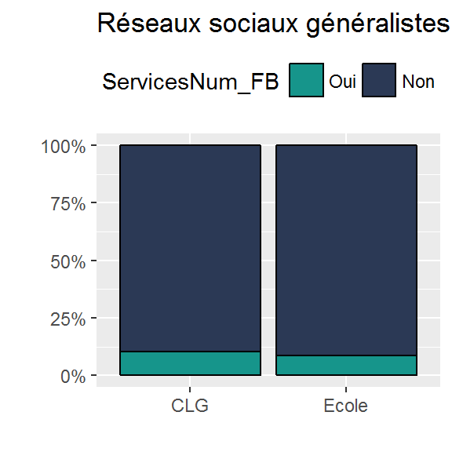

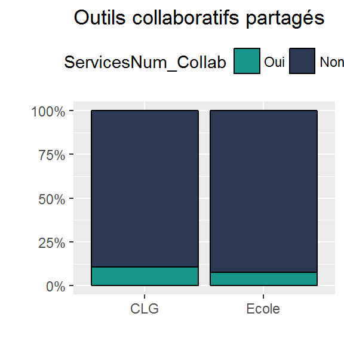

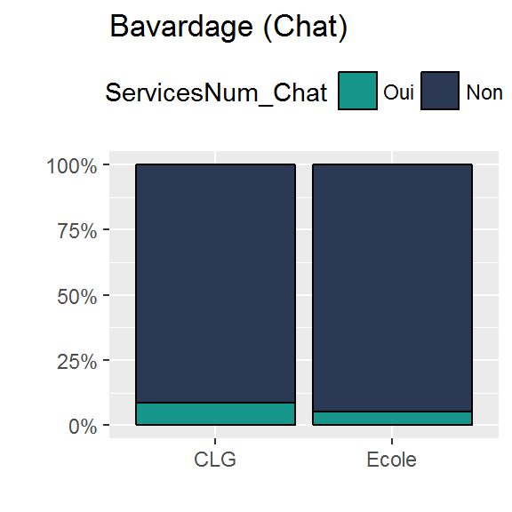

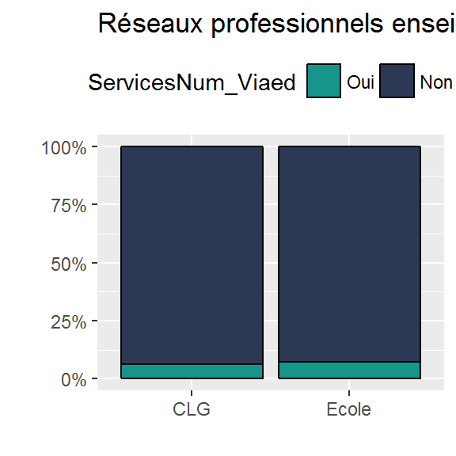

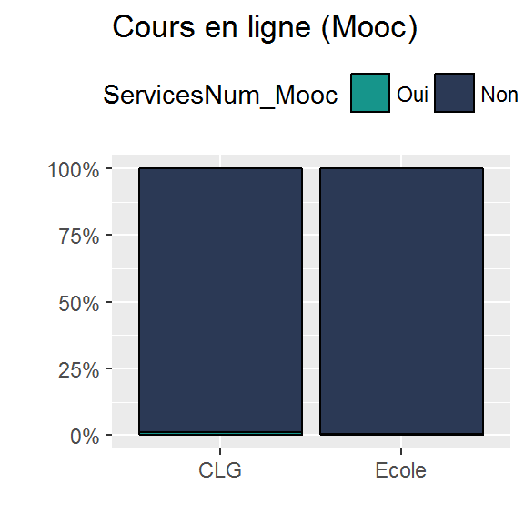

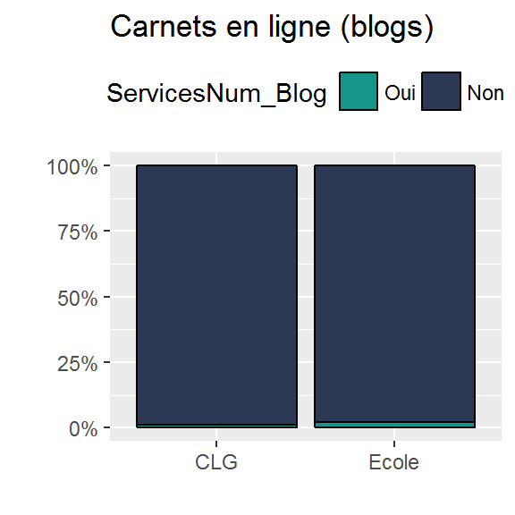

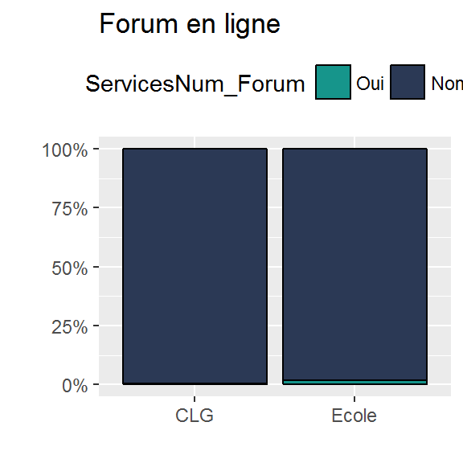

[2 more figures not shown]

## Usage individuel des services numériques

86 enseignants des collèges et 69 des écoles déclarent utiliser au moins un service numérique pour leur travail pédagogique.

*Pour mon travail pédagogique, j’utilise les services numériques suivants:*

| `ServicesNum_` | Effectif au collège | Effectif en élémentaire | % au collège | % en élémentaire | % Global |
| --- | --- | --- | --- | --- | --- |
| Courriel (e-mail) `Mail` | 52 | 34 | 60.5 | 49.3 | 55.5 |
| SMS `Sms` | 11 | 11 | 12.8 | 15.9 | 14.2 |
| Sites web `Web` | 70 | 50 | 81.4 | 72.5 | 77.4 |
| Espace Numérique de Travail `ENT` | 63 | 6 | 73.3 | 8.7 | 44.5 |
| Stockage et partage de fichiers `Drive` | 15 | 9 | 17.4 | 13 | 15.5 |
| Réseaux sociaux généralistes `FB` | 14 | 14 | 16.3 | 20.3 | 18.1 |
| Outils collaboratifs partagés `Collab` | 8 | 5 | 9.3 | 7.2 | 8.4 |
| Bavardage (Chat) `Chat` | 3 | 3 | 3.5 | 4.3 | 3.9 |
| Réseaux professionnels enseignants `Viaed` | 14 | 11 | 16.3 | 15.9 | 16.1 |
| Cours en ligne (Mooc) `Mooc` | 4 | 5 | 4.7 | 7.2 | 5.8 |
| Carnets en ligne (blogs) `Blog` | 2 | 6 | 2.3 | 8.7 | 5.2 |
| Forum en ligne `Forum` | 5 | 5 | 5.8 | 7.2 | 6.5 |
| Visio-conférence `Skype` | 1 | 1 | 1.2 | 1.4 | 1.3 |
| autre service `other` | 2 | 3 | 2.3 | 4.3 | 3.2 |
| TOTAL | 86 | 69 |  |  | n =155 |

`Mail` (p 21.9%) `Sms` (p 74.4%) `Web` (p 25.9%) `ENT` (p 3.410^{-13}%) `Drive` (p 59.7%) `FB` (p 66.4%) `Collab` (p 86.7%) `Chat` (p 100%) `Viaed` (p 100%) `Mooc` (p 73.3%) `Blog` (p 15.7%) `Forum` (p 97.5%) `Skype` (p 100%) `other` (p 80.2%)

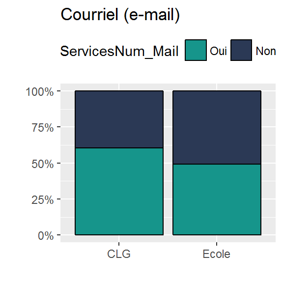

[figure not shown]

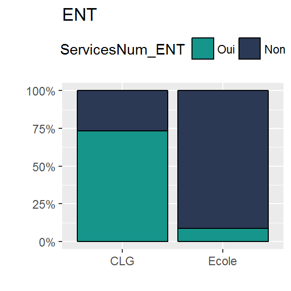

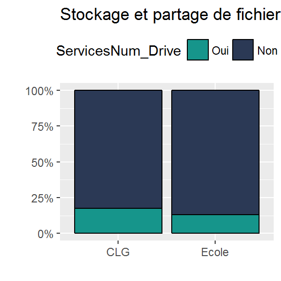

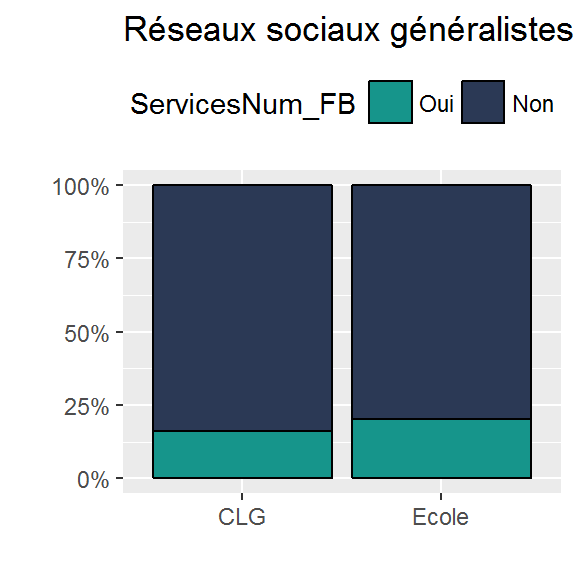

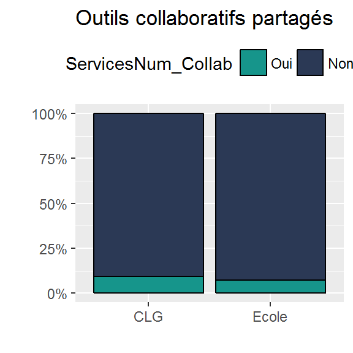

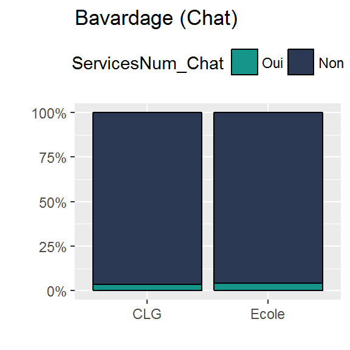

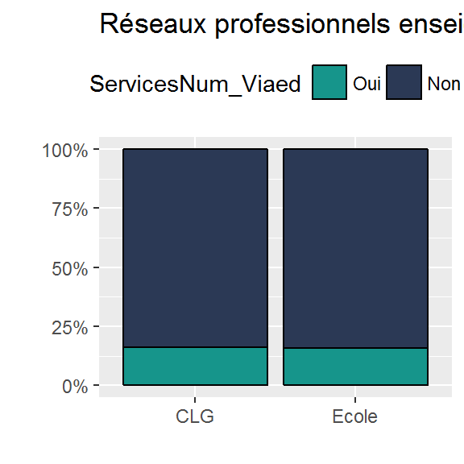

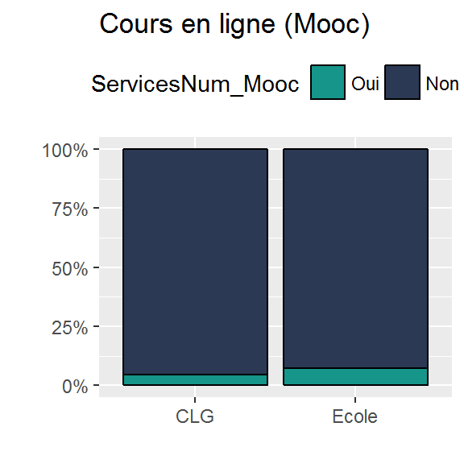

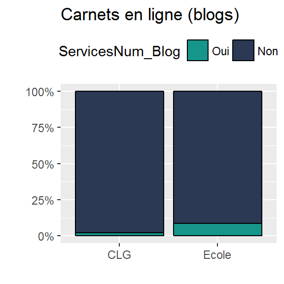

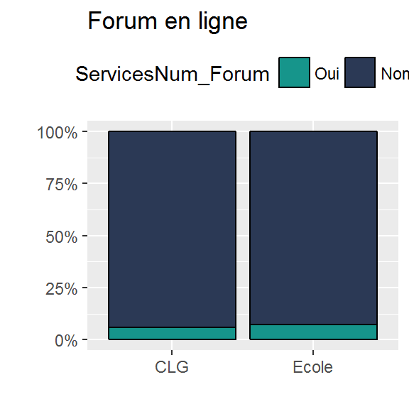

[figure not shown]

[1 more figures not shown]

# 14)* En 1h de travail avec mes collègues, j’utilise ces supports et services numériques pendant environ :

Parmi les 783 enseignants ayant ayant utilisé un support numérique pour préparer une activité avec leurs collègues depuis septembre 2017, 289 (36.9%) déclarent utiliser des supports et services numériques pendant environ 15 à 30mn par heure de travail avec leurs collègues.

`WCollabPcNum` (p 5.1%)

|  | #Total | CLG | Ecole |
| --- | --- | --- | --- |
| dHC$WCollabPcNum |  |  |  |
| Moins de 15mn. | 46 | 49.8 | 40.3 |
| entre 15 et 30mn. | 36.9 | 34.9 | 39.9 |
| entre 30 et 45mn. | 11.9 | 10.2 | 14.4 |
| plus de 45mn. | 5.2 | 5.1 | 5.4 |
| #Total cases | 783 | 470 | 313 |

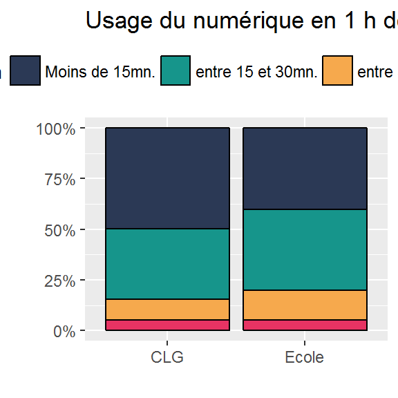

# D. Le travail collectif des élèves

# 18)* Depuis septembre 2017, j’ai globalement fait travailler mes élèves en groupe:

`WEleveGpeFreq` (p 1.610^{-9}%)

|  | #Total | CLG | Ecole |
| --- | --- | --- | --- |
| dH$WEleveGpeFreq |  |  |  |
| Non | 1.1 | 1.4 | 0.8 |
| An | 2.2 | 3.5 | 0.3 |
| Trimestre | 8.7 | 12.3 | 3.5 |
| Mois | 29.8 | 33.6 | 24.4 |
| Hebdo | 38.5 | 31.8 | 48.1 |
| Jour | 19.7 | 17.4 | 22.9 |
| #Total cases | 972 | 575 | 397 |

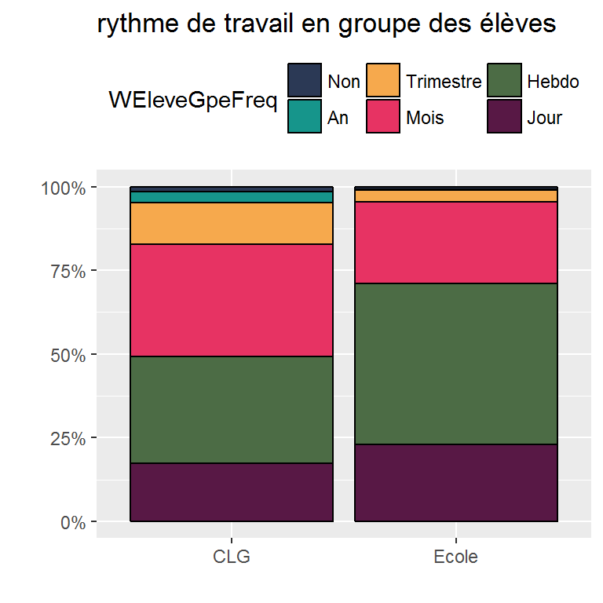

## Travail en groupe fractionné

Parmi les 961 enseignants ayant validé l’ensemble du questionnaire et fait travailler leurs élèves en groupe au moins une fois par an, 578 (60.1%) ont, depuis septembre 2017, globalement fait travailler leurs élèves en groupe en répartissant le travail en plusieurs fois.

`WEFraction` (p 1.3%)

|  | #Total | CLG | Ecole |
| --- | --- | --- | --- |
| dHG$WEFraction |  |  |  |
| en réalisant l’activité en une seule fois | 39.9 | 43.2 | 35 |
| en répartissant le travail en plusieurs fois | 60.1 | 56.8 | 65 |
| #Total cases | 961 | 567 | 394 |

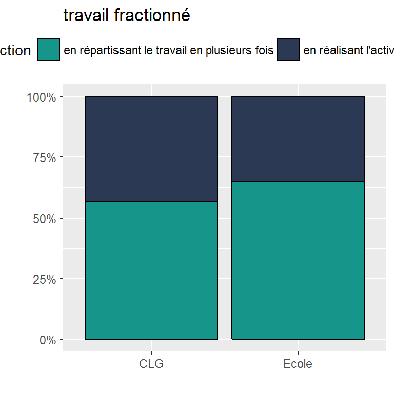

## Travail en groupe hors temps scolaire

Parmi les 961 enseignants ayant validé l’ensemble du questionnaire et fait travailler leurs élèves en groupe au moins une fois par an, 195 (20.3%) ont, depuis septembre 2017, aussi fait travailler leurs élèves en groupe hors du temps scolaire.

*j’ai aussi fait travailler mes élèves en groupe hors du temps scolaire :*

`WEExtra` (p 0.3%)

|  | #Total | CLG | Ecole |
| --- | --- | --- | --- |
| dHG$WEExtra |  |  |  |
| Non | 79.7 | 76.4 | 84.5 |
| Oui | 20.3 | 23.6 | 15.5 |
| #Total cases | 961 | 567 | 394 |

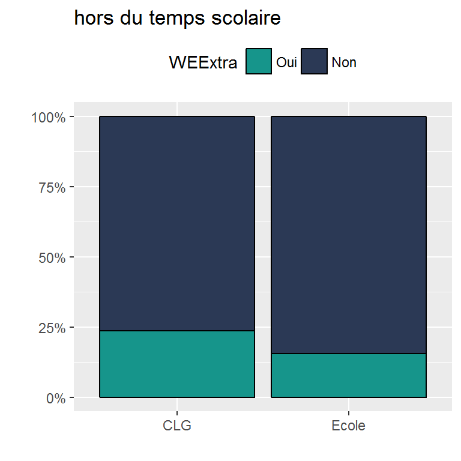

# 19)* La dernière séquence de travail collectif de vos élèves a duré:

Parmi les 961 enseignants ayant validé l’ensemble du questionnaire et fait travailler leurs élèves en groupe, 516 (53.7%) déclarent que leur dernière séquence de travail collectif a duré entre 30 et 60mn.

`WEleveGpeTps` (p 9.810^{-11}%)

|  | #Total | CLG | Ecole |
| --- | --- | --- | --- |
| dHG$WEleveGpeTps |  |  |  |
| plus d’1h30 | 5.1 | 8.3 | 0.5 |
| entre 1h et 1h30 | 6.3 | 9.2 | 2.3 |
| entre 30 et 60mn. | 53.7 | 53.6 | 53.8 |
| Moins de 30mn. | 34.9 | 28.9 | 43.4 |
| #Total cases | 961 | 567 | 394 |

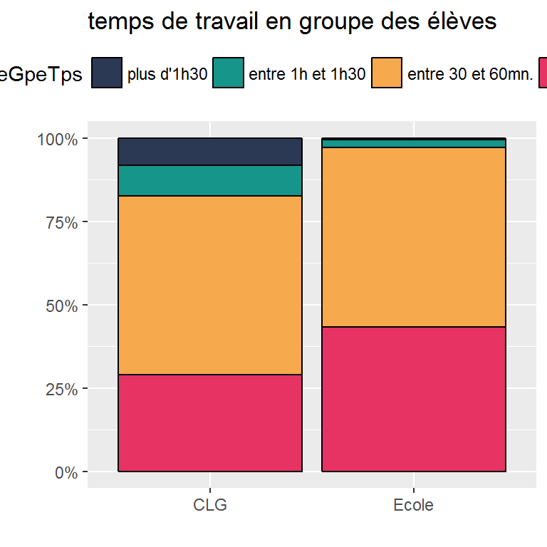

# 20)* D’après mon expérience, la taille idéale d’un groupe d’élèves est de:

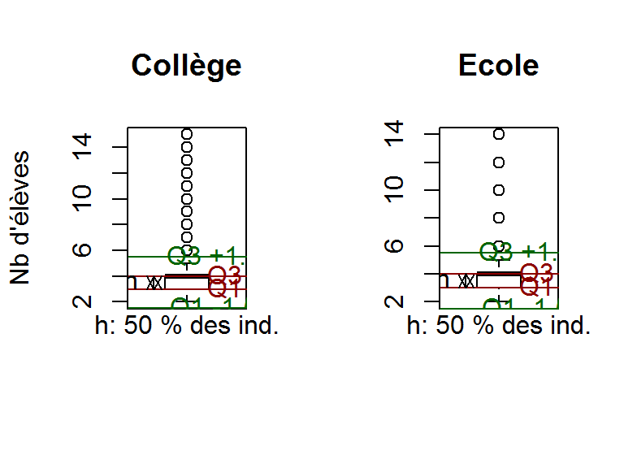

Parmi les 961 enseignants ayant validé l’ensemble du questionnaire et fait travailler leurs élèves en groupe, 460 (47.9%) estiment d’après leur expérience, que le groupe idéal est de 4 élèves

`GpeEleveSize.reg` (p 0%)

|  | #Total | CLG | Ecole |
| --- | --- | --- | --- |
| dHG$GpeEleveSize.reg |  |  |  |
| plus de 5 | 15 | 18.5 | 9.9 |
| 5 | 7.8 | 5.5 | 11.2 |
| 4 | 47.9 | 44.3 | 53 |
| 3 | 24.1 | 26.1 | 21.3 |
| 2 | 5.2 | 5.6 | 4.6 |
| #Total cases | 961 | 567 | 394 |

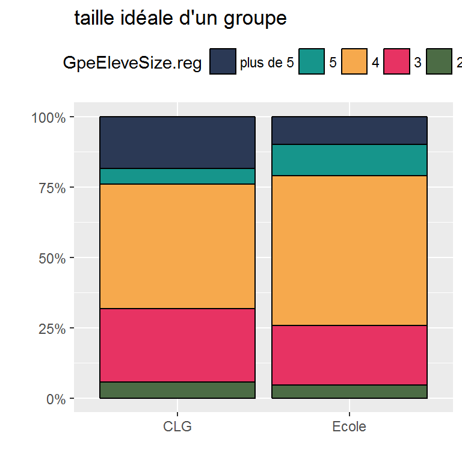

# 21)* Durant les activités en groupe, les tâches sont le plus souvent:

Parmi les 961 enseignants ayant validé l’ensemble du questionnaire et fait travailler leurs élèves en groupe au moins une fois par an, 199 (20.7%) font le plus souvent repréciser les tâches par les élèves.

*re-précisées par:*

`TaskIdent` (p 410^{-6}%)

|  | #Total | CLG | Ecole |
| --- | --- | --- | --- |
| dHG$TaskIdent |  |  |  |
| mes soins | 79.3 | 85.4 | 70.6 |
| les élèves | 20.7 | 14.6 | 29.4 |
| #Total cases | 961 | 567 | 394 |

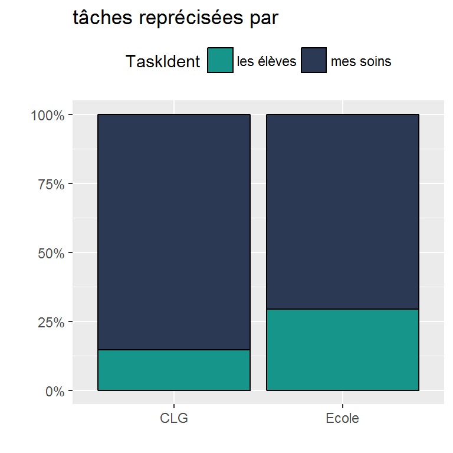

Parmi les 961 enseignants ayant validé l’ensemble du questionnaire et fait travailler leurs élèves en groupe au moins une fois par an, 39 n’ont pas indiqué comment les tâches sont le plus souvent réparties. 327 (35.5% des répondants à cette question) déclarent que les tâches sont le plus souvent réparties entre les élèves sur l’initiative de l’enseignant.

*les tâches sont le plus souvent:*

`TaskDistrib` (p 11.2%)

|  | #Total | CLG | Ecole |
| --- | --- | --- | --- |
| dHG$TaskDistrib |  |  |  |
| identiques pour tous | 9.2 | 10.9 | 6.8 |
| réparties entre les élèves sur mon initiative | 35.5 | 34.7 | 36.6 |
| réparties entre les élèves sur leur initiative | 55.3 | 54.4 | 56.6 |
| #Total cases | 922 | 542 | 380 |

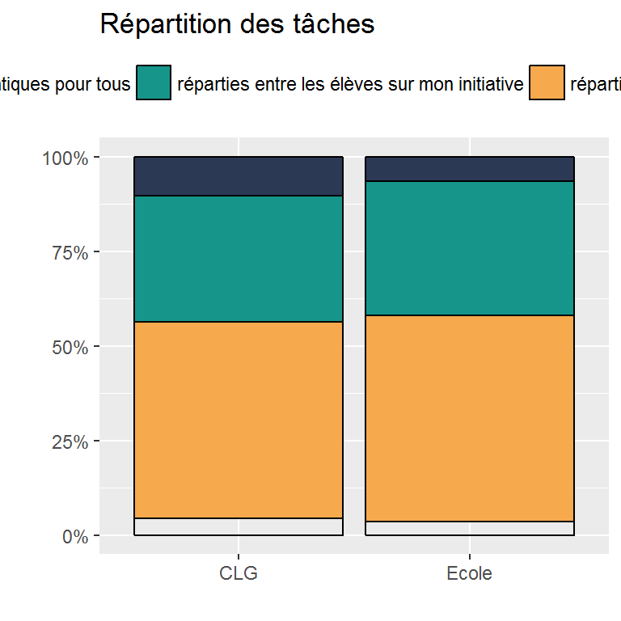

# 22)* En classe, je fais travailler les élèves en groupe pour les activités suivantes:

Parmi les 961 enseignants ayant validé l’ensemble du questionnaire et fait travailler leurs élèves en groupe au moins une fois par an, 624 (64.9%) font travailler les élèves en groupe pour des activités d’entraide (mentorat, tutorat, aide par les pairs).

| Activités de groupe `WE_` | CLG | Ecole | % CLG | % Ecole | % Global |
| --- | --- | --- | --- | --- | --- |
| entraide (mentorat, tutorat, aide par les pairs) `Aide` | 308 | 316 | 54.3 | 80.2 | 64.9 |
| exploration (découverte d’une notion, recherches) `Explo` | 355 | 291 | 62.6 | 73.9 | 67.2 |
| résolution de problèmes (énigmes, défis, concours) `Pb` | 244 | 276 | 43 | 70.1 | 54.1 |
| expérimentation (tests, exercices pratiques) `Expe` | 290 | 272 | 51.1 | 69 | 58.5 |
| écriture (fiction, théâtre, poésie) `Ecrit` | 179 | 188 | 31.6 | 47.7 | 38.2 |
| communication (échanges, correspondances, rencontres) `Com` | 231 | 125 | 40.7 | 31.7 | 37 |
| création d’événements `Even` | 112 | 101 | 19.8 | 25.6 | 22.2 |
| Autre: `Other` | 26 | 16 | 4.6 | 4.1 | 4.4 |
| Total | 567 | 394 |  |  | 961 |

Autres activités:

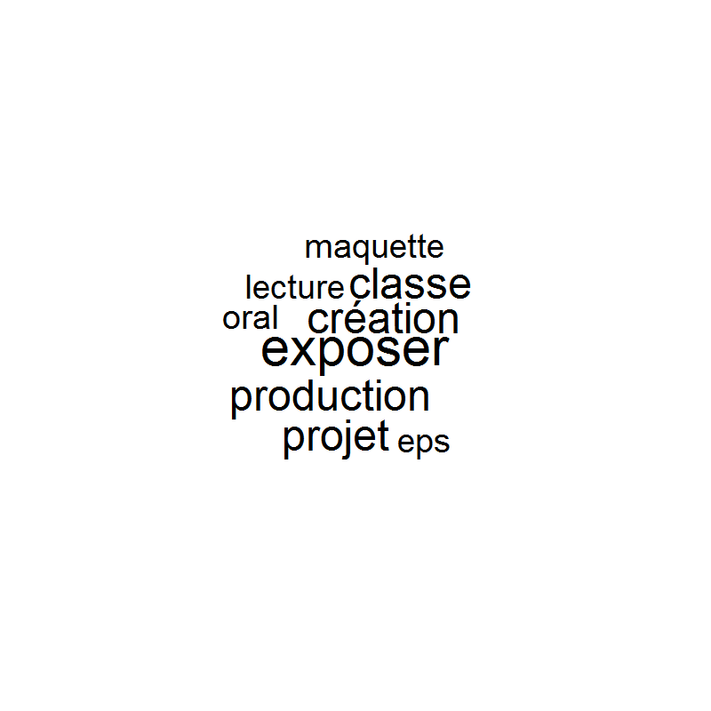

`Aide` (p 2.410^{-14}%) `Explo` (p 0%) `Pb` (p 2.410^{-14}%) `Expe` (p 4.510^{-6}%) `Ecrit` (p 5.810^{-5}%) `Com` (p 0.5%) `Even` (p 3.8%) `other` (p 81.7%)

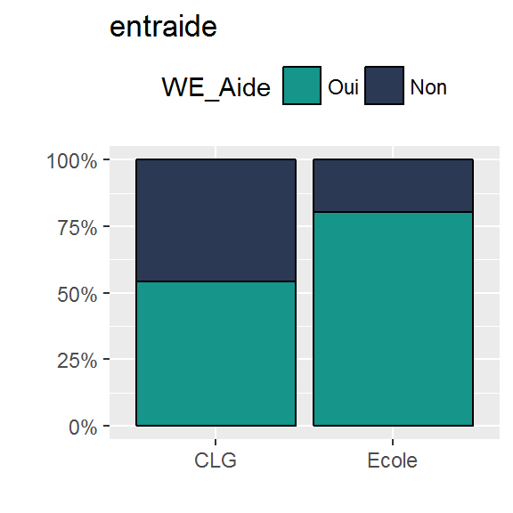

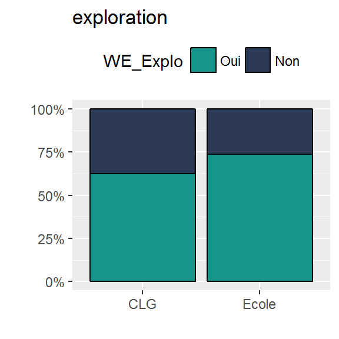

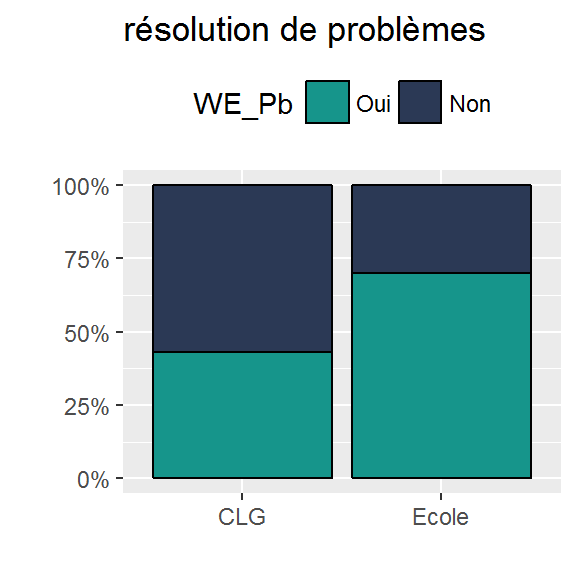

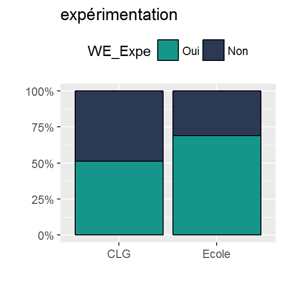

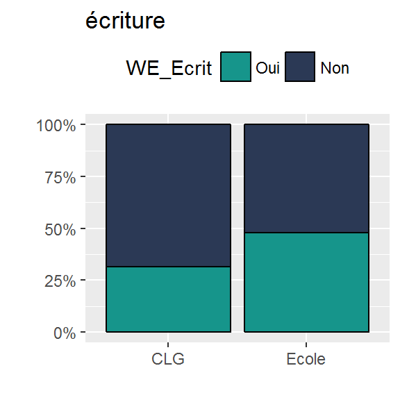

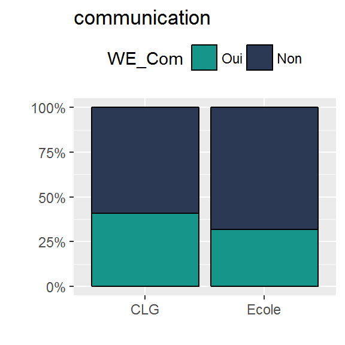

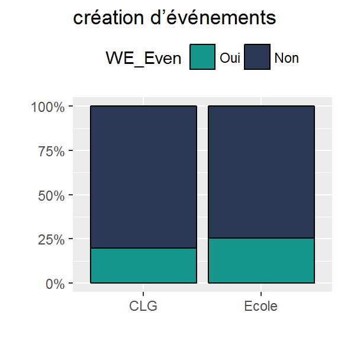

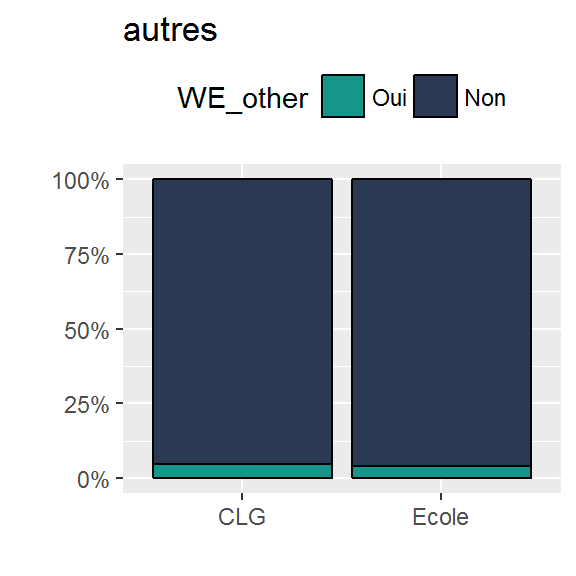

# 23)* Je pense que le travail des élèves en groupe est davantage adapté aux activités:

Parmi les 972 enseignants ayant validé l’ensemble du questionnaire, 639 (65.7%) pensent que le travail des élèves en groupe est davantage adapté aux activités thématiques.

| travail en groupe adapté aux activités: | CLG | Ecole | % CLG | % Ecole | % Global |
| --- | --- | --- | --- | --- | --- |
| thématiques `ActThema` | 359 | 280 | 62.4 | 70.5 | 65.7 |
| disciplinaires `ActDisc` | 403 | 243 | 70.1 | 61.2 | 66.5 |
| inter-disciplinaires `ActInterDisc` | 303 | 221 | 52.7 | 55.7 | 53.9 |
| inter-classes `ActInterCl` | 109 | 103 | 19 | 25.9 | 21.8 |
| inter-établissements `ActInterEtab` | 88 | 51 | 15.3 | 12.8 | 14.3 |
| Total | 575 | 397 |  |  | 972 |

`ActDisc.regC` (p 0.5%) `ActThema.regC` (p 1.1%) `ActInterDisc.regC` (p 39.6%) `ActInterCl.regC` (p 1.2%) `ActInterEtab.regC` (p 32.6%)

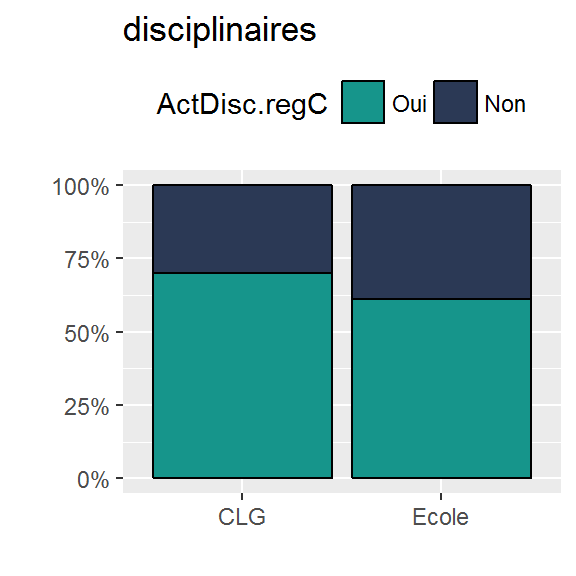

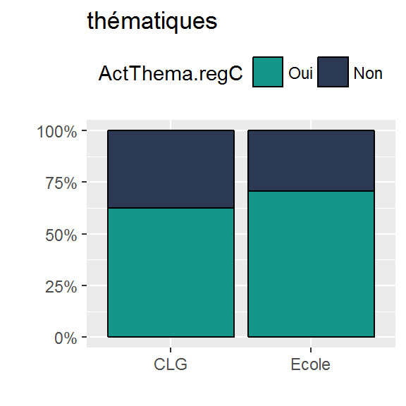

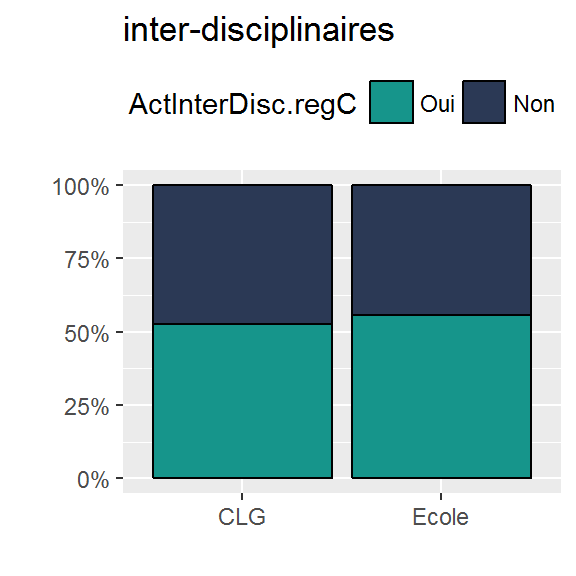

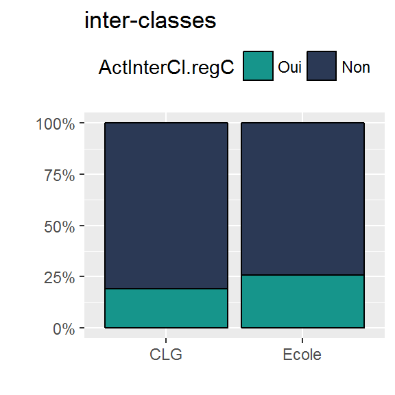

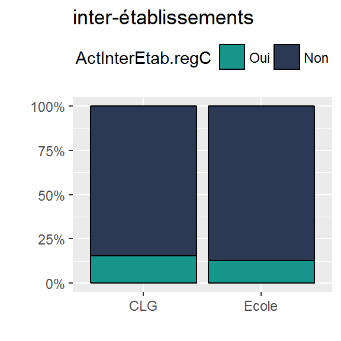

# 24)* Je pense que travailler en groupe permet à mes élèves de :

| permet à mes élèves de: | CLG | Ecole | % CLG | % Ecole | % Global |
| --- | --- | --- | --- | --- | --- |
| argumenter à l’oral de façon claire `SC111` | 276 | 238 | 48 | 59.9 | 52.9 |
| employer à l’écrit comme à l’oral un vocabulaire juste et précis `SC113` | 170 | 117 | 29.6 | 29.5 | 29.5 |
| concevoir et réaliser des productions, visuelles, plastiques, sonores ou verbales `SC141` | 333 | 206 | 57.9 | 51.9 | 55.5 |
| choisir les démarches adaptées aux objectifs d’apprentissage préalablement explicités `SC204` | 212 | 127 | 36.9 | 32 | 34.9 |
| analyser et exploiter les erreurs, mettre à l’essai plusieurs solutions `SC215` | 338 | 273 | 58.8 | 68.8 | 62.9 |
| apprendre à gérer un projet, qu’il soit individuel ou collectif`SC222` | 421 | 278 | 73.2 | 70 | 71.9 |
| apprendre à confronter différentes sources et à évaluer la validité des contenus `SC234` | 279 | 219 | 48.5 | 55.2 | 51.2 |
| utiliser les espaces collaboratifs et apprendre à communiquer `SC243` | 319 | 212 | 55.5 | 53.4 | 54.6 |
| exprimer leurs sentiments et leurs émotions `SC311` | 234 | 160 | 40.7 | 40.3 | 40.5 |
| mettre à distance préjugés et stéréotypes, apprécier les personnes qui sont différentes d’eux et vivre avec elles `SC315` | 295 | 171 | 51.3 | 43.1 | 47.9 |
| participer à la définition de règles communes dans le cadre adéquat `SC322` | 258 | 187 | 44.9 | 47.1 | 45.8 |
| fonder et défendre leurs jugements en s’appuyant sur leur réflexion et sur leur maîtrise de l’argumentation`SC332` | 301 | 241 | 52.3 | 60.7 | 55.8 |
| pratiquer des démarches scientifiques et techniques `SC404` | 223 | 262 | 38.8 | 66 | 49.9 |
| développer des capacités d’imagination, de conception, d’action`SC505` | 309 | 188 | 53.7 | 47.4 | 51.1 |
| Total | 575 | 397 |  |  | 972 |

`SC111.regC` (p 0%) `SC113.regC` (p 100%) `SC141.regC` (p 7.3%) `SC204.regC` (p 13.3%) `SC215.regC` (p 0.2%) `SC222.regC` (p 31%) `SC234.regC` (p 4.9%)

`SC243.regC` (p 56.6%) `SC311.regC` (p 95.5%) `SC315.regC` (p 1.4%) `SC322.regC` (p 53.4%) `SC332.regC` (p 1.2%) `SC404.regC` (p 1.310^{-14}%) `SC505.regC` (p 5.9%)

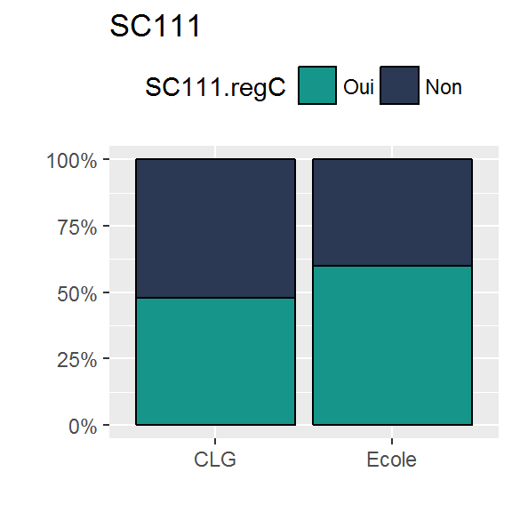

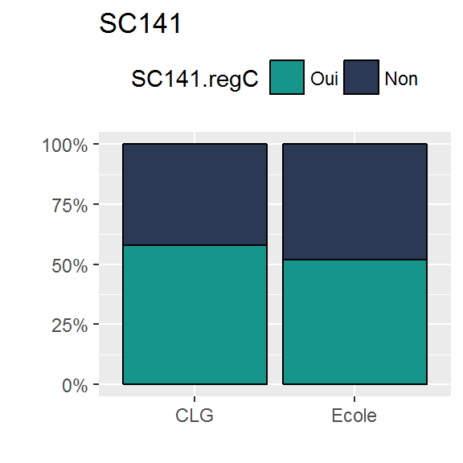

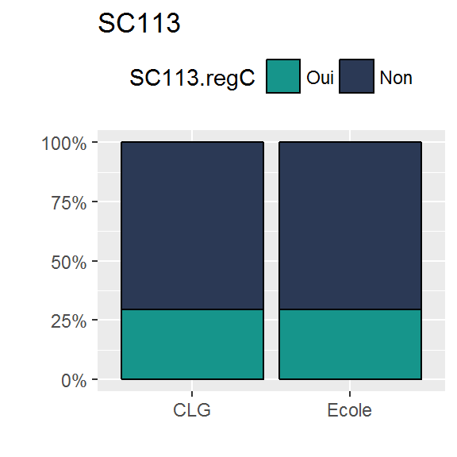

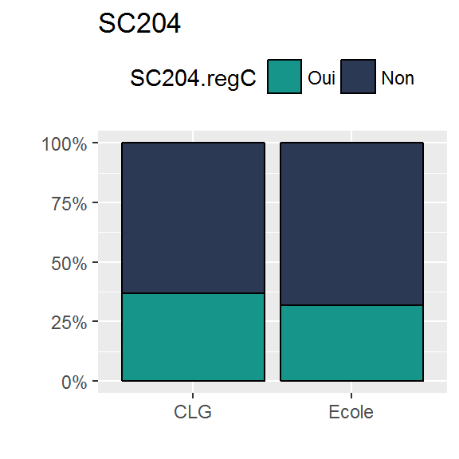

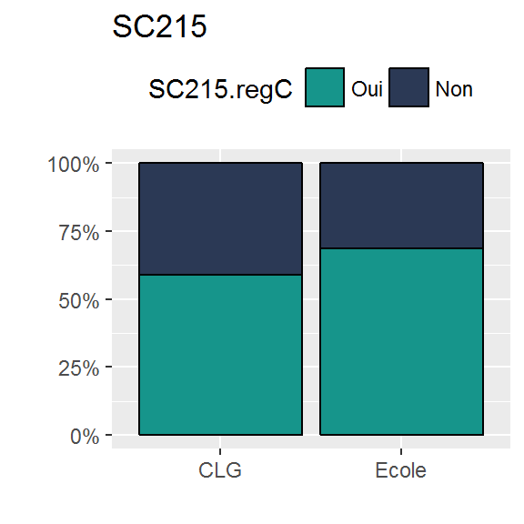

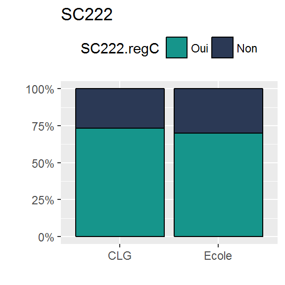

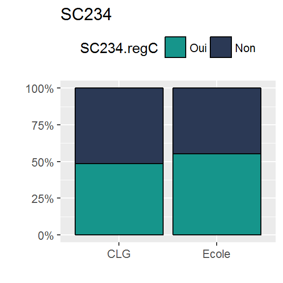

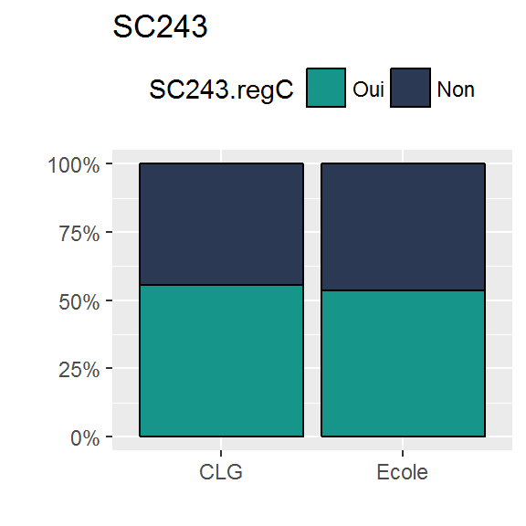

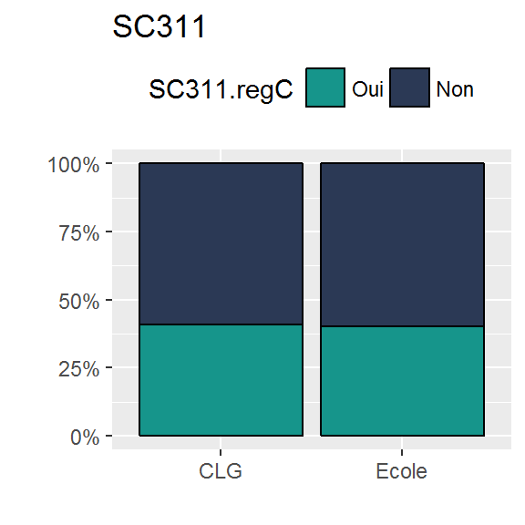

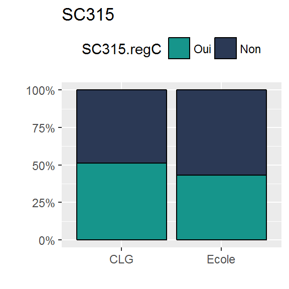

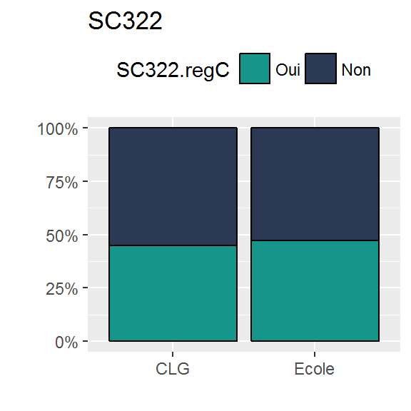

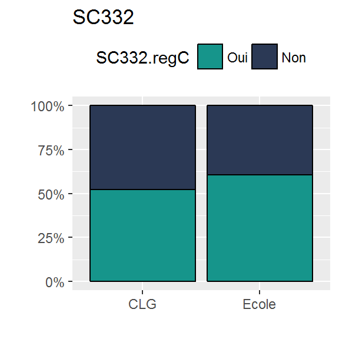

[2 more figures not shown]

# 25)* Quels types d’évaluations utilisez-vous, pour les travaux en groupe?

Parmi les 972 enseignants ayant validé l’ensemble du questionnaire, 566 (58.2%) utilisent des évaluations collectives, pour les travaux en groupe.

| `Eval`: | CLG | Ecole | % CLG | % Ecole | % Global |
| --- | --- | --- | --- | --- | --- |
| évaluation sommative `EvalSommative` | 222 | 62 | 38.6 | 15.6 | 29.2 |
| évaluation formative `EvalFormative` | 306 | 176 | 53.2 | 44.3 | 49.6 |
| évaluation diagnostique `EvalDiagnostique` | 123 | 76 | 21.4 | 19.1 | 20.5 |
| évaluation collective `EvalCollective` | 351 | 215 | 61 | 54.2 | 58.2 |
| évaluation individuelle`EvalIndividuelle` | 255 | 76 | 44.3 | 19.1 | 34.1 |
| auto-évaluation entre élèves `EvalAuto` | 231 | 142 | 40.2 | 35.8 | 38.4 |
| Total | 575 | 397 |  |  | 972 |

`EvalSommative.regC` (p 1.610^{-12}%) `EvalFormative.regC` (p 0.8%) `EvalDiagnostique.regC` (p 44%) `EvalCollective.regC` (p 3.8%) `EvalIndividuelle.regC` (p 6.410^{-14}%) `EvalAuto.regC` (p 18.6%)

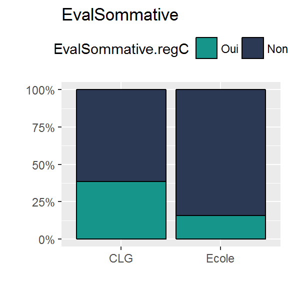

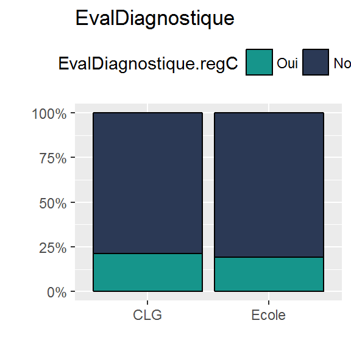

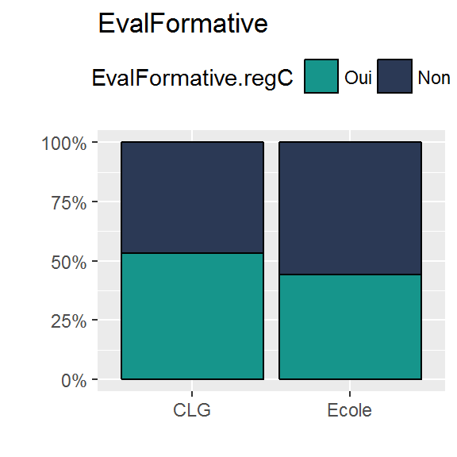

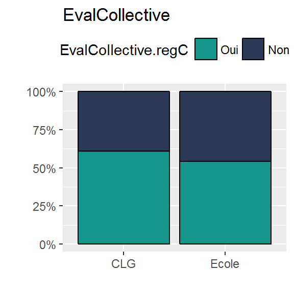

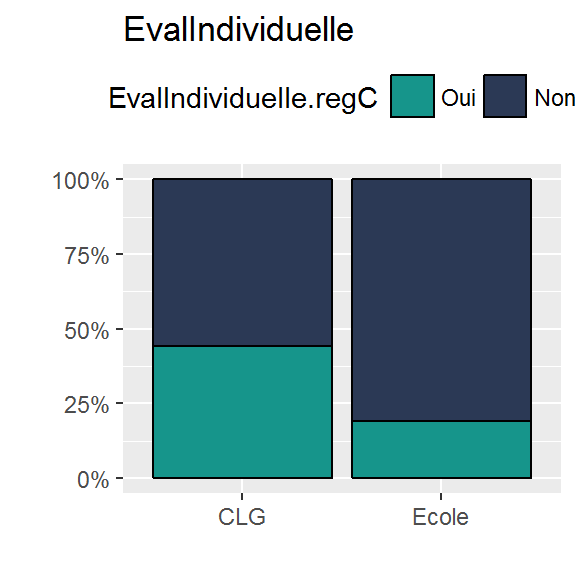

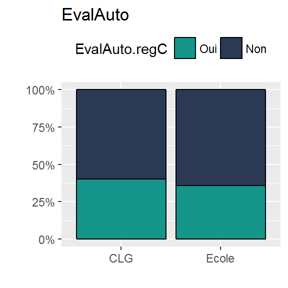

# 26)* Incluez-vous aussi la collaboration des élèves dans ces types d’évaluations?

Parmi les 972 enseignants qui ont renseigné l’ensemble du questionnaire, 627 (64.5%) ont déclaré évaluer aussi la collaboration de leurs élèves dans les évaluations pour les travaux de groupe.

`EvalCollabEleve` (p 95.5%)

|  | #Total | CLG | Ecole |
| --- | --- | --- | --- |
| dH$EvalCollabEleve |  |  |  |
| Non | 35.5 | 35.7 | 35.3 |
| Oui | 64.5 | 64.3 | 64.7 |
| #Total cases | 972 | 575 | 397 |

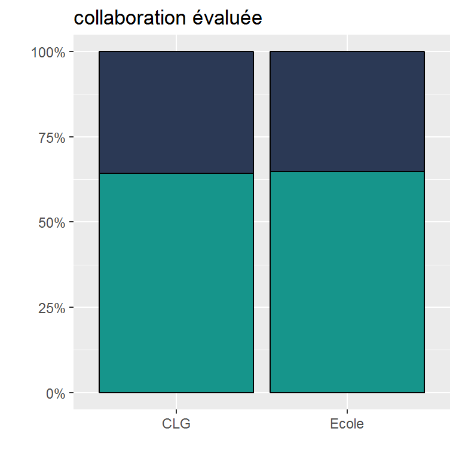